# Cupcake Analysis

Eric R. Scott

```r
library(tidyverse)
library(ropls)
library(MVN)
library(chemhelper)
library(latex2exp)
library(here)
library(cowplot)
```

# Load Data

```r
recipes_wide <- read_rds("/Users/scottericr/Documents/Tufts/cupcakes-vs-muffins/recipes_wide.rds")
```

# Check multivariate normality

| Test | Statistic | p value | Result |
| --- | --- | --- | --- |
| Mardia Skewness | 88509.6485640073 | 0 | NO |
| Mardia Kurtosis | 204.408619329153 | 0 | NO |
| MVN | NA | NA | NO |

|  | Test | Variable | Statistic | p value | Normality |
| --- | --- | --- | --- | --- | --- |
| 1 | Shapiro-Wilk | agave | 0.0561 | <0.001 | NO |
| 2 | Shapiro-Wilk | baking powder | 0.8712 | <0.001 | NO |
| 3 | Shapiro-Wilk | baking soda | 0.8266 | <0.001 | NO |
| 4 | Shapiro-Wilk | bran | 0.1329 | <0.001 | NO |
| 5 | Shapiro-Wilk | butter | 0.8170 | <0.001 | NO |
| 6 | Shapiro-Wilk | buttermilk | 0.3952 | <0.001 | NO |
| 7 | Shapiro-Wilk | cheese | 0.0562 | <0.001 | NO |
| 8 | Shapiro-Wilk | chocolate | 0.6221 | <0.001 | NO |
| 9 | Shapiro-Wilk | cornmeal | 0.1194 | <0.001 | NO |
| 10 | Shapiro-Wilk | cream | 0.2713 | <0.001 | NO |

[output cut: 30 more lines]

|  | n | Mean | Std.Dev | Median | Min | Max | 25th | 75th | Skew | Kurtosis |
| --- | --- | --- | --- | --- | --- | --- | --- | --- | --- | --- |
| agave | 269 | 2.323420e-04 | 0.0028360799 | 0.0000000000 | 0.000000000 | 0.041666667 | 0.0000000000 | 0.0000000000 | 13.0166579 | 176.7113164 |
| baking powder | 269 | 1.605474e-03 | 0.0016112449 | 0.0013020812 | 0.000000000 | 0.006944433 | 0.0000000000 | 0.0026041625 | 1.0162441 | 0.6704409 |
| baking soda | 269 | 7.938269e-04 | 0.0008996951 | 0.0005787028 | 0.000000000 | 0.005208325 | 0.0000000000 | 0.0013020812 | 1.3284911 | 2.1207477 |
| bran | 269 | 2.664188e-03 | 0.0177873062 | 0.0000000000 | 0.000000000 | 0.145833333 | 0.0000000000 | 0.0000000000 | 6.8469400 | 46.0660598 |
| butter | 269 | 2.320385e-02 | 0.0276772583 | 0.0138888889 | 0.000000000 | 0.142857143 | 0.0000000000 | 0.0416666667 | 1.1633070 | 1.0101213 |
| buttermilk | 269 | 6.263645e-03 | 0.0181177716 | 0.0000000000 | 0.000000000 | 0.097222222 | 0.0000000000 | 0.0000000000 | 3.0771130 | 8.9851968 |
| cheese | 269 | 7.495796e-04 | 0.0091362281 | 0.0000000000 | 0.000000000 | 0.133928571 | 0.0000000000 | 0.0000000000 | 12.9776108 | 175.5759392 |
| chocolate | 269 | 1.754532e-02 | 0.0319829480 | 0.0000000000 | 0.000000000 | 0.156250000 | 0.0000000000 | 0.0217013875 | 2.1746871 | 4.5081935 |
| cornmeal | 269 | 1.368236e-03 | 0.0098808213 | 0.0000000000 | 0.000000000 | 0.083333333 | 0.0000000000 | 0.0000000000 | 7.5036870 | 56.2948926 |
| cream | 269 | 3.326040e-03 | 0.0133888890 | 0.0000000000 | 0.000000000 | 0.098958333 | 0.0000000000 | 0.0000000000 | 4.6094891 | 22.4442124 |

[output cut: 30 more lines]

```
NA
```

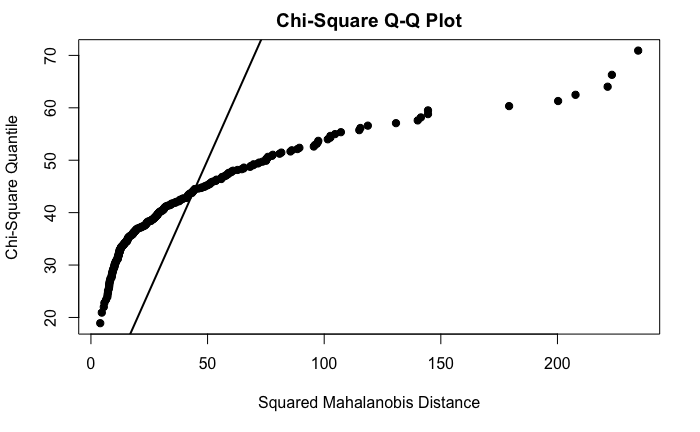

```r
mvn(select_if(recipes_wide, is.double), scale = TRUE, multivariatePlot = "qq")
```

| Test | Statistic | p value | Result |
| --- | --- | --- | --- |
| Mardia Skewness | 64910.3069154369 | 0 | NO |
| Mardia Kurtosis | 130.195494986533 | 0 | NO |
| MVN | NA | NA | NO |

|  | Test | Variable | Statistic | p value | Normality |
| --- | --- | --- | --- | --- | --- |
| 1 | Shapiro-Wilk | agave | 0.0589 | <0.001 | NO |
| 2 | Shapiro-Wilk | baking powder | 0.8922 | <0.001 | NO |
| 3 | Shapiro-Wilk | baking soda | 0.8591 | <0.001 | NO |
| 4 | Shapiro-Wilk | bran | 0.1419 | <0.001 | NO |
| 5 | Shapiro-Wilk | butter | 0.8330 | <0.001 | NO |
| 6 | Shapiro-Wilk | buttermilk | 0.4203 | <0.001 | NO |
| 7 | Shapiro-Wilk | cheese | 0.0589 | <0.001 | NO |
| 8 | Shapiro-Wilk | chocolate | 0.6971 | <0.001 | NO |
| 9 | Shapiro-Wilk | cornmeal | 0.1277 | <0.001 | NO |
| 10 | Shapiro-Wilk | cream | 0.3050 | <0.001 | NO |

[output cut: 30 more lines]

|  | n | Mean | Std.Dev | Median | Min | Max | 25th | 75th | Skew | Kurtosis |
| --- | --- | --- | --- | --- | --- | --- | --- | --- | --- | --- |
| agave | 269 | 0.0012953967 | 0.01521593 | 0.00000000 | 0.00000000 | 0.20412415 | 0.00000000 | 0.00000000 | 11.89308738 | 143.40808066 |
| baking powder | 269 | 0.0317693695 | 0.02446234 | 0.03608436 | 0.00000000 | 0.08333327 | 0.00000000 | 0.05103100 | -0.05812677 | -1.20398830 |
| baking soda | 269 | 0.0210289410 | 0.01878623 | 0.02405624 | 0.00000000 | 0.07216873 | 0.00000000 | 0.03608436 | 0.16022186 | -1.24361435 |
| bran | 269 | 0.0080447555 | 0.05108003 | 0.00000000 | 0.00000000 | 0.38188131 | 0.00000000 | 0.00000000 | 6.40530488 | 40.16039900 |
| butter | 269 | 0.1086500409 | 0.10696520 | 0.11785113 | 0.00000000 | 0.37796447 | 0.00000000 | 0.20412415 | 0.27197151 | -1.39423700 |
| buttermilk | 269 | 0.0279622472 | 0.07417690 | 0.00000000 | 0.00000000 | 0.31180478 | 0.00000000 | 0.00000000 | 2.45099265 | 4.53282920 |
| cheese | 269 | 0.0023277724 | 0.02733016 | 0.00000000 | 0.00000000 | 0.36596253 | 0.00000000 | 0.00000000 | 11.87865083 | 142.97208211 |
| chocolate | 269 | 0.0736594369 | 0.11029430 | 0.00000000 | 0.00000000 | 0.39528471 | 0.00000000 | 0.14731391 | 1.15674043 | 0.01169219 |
| cornmeal | 269 | 0.0053457274 | 0.03666958 | 0.00000000 | 0.00000000 | 0.28867513 | 0.00000000 | 0.00000000 | 6.94483711 | 47.65354352 |
| cream | 269 | 0.0154989776 | 0.05565372 | 0.00000000 | 0.00000000 | 0.31457643 | 0.00000000 | 0.00000000 | 3.62643407 | 12.26017511 |

[output cut: 30 more lines]

```
NA
```

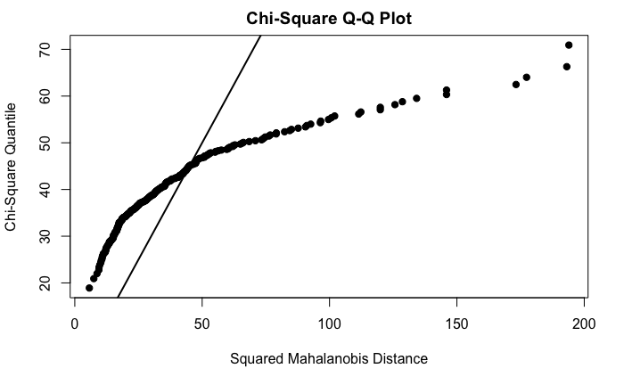

```r
mvn(select_if(recipes_wide, is.double), scale = TRUE, transform = "sqrt", multivariatePlot = "qq")
```

No, not multivariate normal and transformations do nothing because of all the zeroes probably.

# Do preliminary PCA

```r
recipe_pca <- opls(select_if(recipes_wide, is.double), scaleC = "standard", plotL = FALSE)
```

```
The maximum number of components for the automated mode (10) has been reached whereas the cumulative variance 46% is still less than 50%.
```

```
PCA
269 samples x 40 variables
standard scaling of predictors
```

|  | R2X(cum) | pre | ort |
| --- | --- | --- | --- |
| Total | 0.463 | 10 | 0 |

```
Character 'parAsColFcVn' set to a factor
```

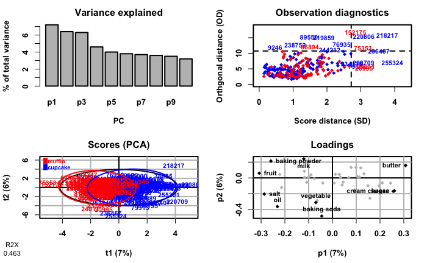

```r
plot(recipe_pca,
     parAsColFcVn = recipes_wide$Type,
     parLabVc = recipes_wide$`Recipe ID`,
     parCompVi = c(1, 2))
```

# PLS-DA

Try with unscaled data. Elizabeth predicts taht in pls-da scaling is less important than in PCA. In this case, at least, scaling reduces R2X (from 0.75 to 0.098), increases R2Y (from 0.41 to 0.62), has only a slight effect on Q2 (from 0.39 to 0.47), and doesn’t effect p-values. It also changes VIP scores substantially.

```r
recipe_plsda <- opls(select_if(recipes_wide, is.double), recipes_wide$Type,
                     scaleC = "none",
                     plotL = FALSE,
                     permI = 200,
                     predI = 2)
```

```
PLS-DA
269 samples x 40 variables and 1 response
none scaling of predictors and standard scaling of response(s)
```

|  | R2X(cum) | R2Y(cum) | Q2(cum) | RMSEE | pre | ort | pR2Y | pQ2 |
| --- | --- | --- | --- | --- | --- | --- | --- | --- |
| Total | 0.75 | 0.413 | 0.391 | 0.371 | 2 | 0 | 0.005 | 0.005 |

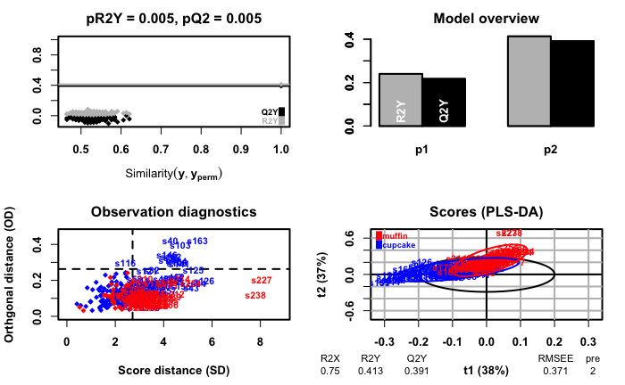

```r
plot(recipe_plsda)
```

```r
get_VIP(recipe_plsda) %>% arrange(desc(VIP))
```

| Variable | VIP |
| --- | --- |
| flour | 3.168267562 |
| sugar | 2.990636160 |
| eggs | 2.779381199 |
| fruit | 2.733452123 |
| unitless | 1.517341134 |
| butter | 0.854697080 |
| cream cheese | 0.780649851 |
| oats | 0.608108145 |
| oil | 0.550812383 |
| chocolate | 0.529421117 |

[output cut: 30 more lines]

```r
getLoadingMN(recipe_plsda) %>% as.data.frame()
```

|  | p1 | p2 |
| --- | --- | --- |
| agave | 0.0016358587 | 0.0013348183 |
| baking powder | -0.0059772852 | 0.0094359959 |
| baking soda | -0.0043710823 | 0.0036230916 |
| bran | 0.0065684279 | 0.0177586346 |
| butter | -0.2619934221 | 0.0770729866 |
| buttermilk | -0.0302887636 | 0.0288001656 |
| cheese | -0.0105761858 | 0.0026101605 |
| chocolate | -0.1707532108 | 0.0431279483 |
| cornmeal | 0.0030094847 | 0.0076082394 |
| cream | -0.0258952173 | 0.0078770289 |

[output cut: 30 more lines]

# Try with reduced dataset

The sample size is unrealistic for an ecological experiment. Try taking a subsample of muffins and cupcakes (n = 20?)

```r
# set.seed(8)
# set.seed(100)
set.seed(25)
recipes_small <- recipes_wide %>% group_by(Type) %>% sample_n(20) %>% ungroup()
#get rid of empty columns
recipes_small <- recipes_small %>% select_if(~is.character(.) | (is.double(.) & var(.) != 0))
```

```
NAs introduced by coercion
```

```r
#get rid of rare ingredients
keepers <- recipes_small %>%
  mutate_if(is.double, ~.!=0) %>%
  summarise_if(is.logical, sum) %>%
  gather() %>%
  filter(value > 2) %>%
  .$key %>% c("Type", "Recipe ID", .)
recipes_small <- recipes_small %>% select_at(vars(keepers))
```

## Check multivariate normality

| Test | Statistic | p value | Result |
| --- | --- | --- | --- |
| Mardia Skewness | 2282.87398963988 | 4.47154274274852e-05 | NO |
| Mardia Kurtosis | 0.314866626401691 | 0.752862921954518 | YES |
| MVN | NA | NA | NO |

|  | Test | Variable | Statistic | p value | Normality |
| --- | --- | --- | --- | --- | --- |
| 1 | Shapiro-Wilk | baking powder | 0.8498 | 1e-04 | NO |
| 2 | Shapiro-Wilk | baking soda | 0.8215 | <0.001 | NO |
| 3 | Shapiro-Wilk | butter | 0.8038 | <0.001 | NO |
| 4 | Shapiro-Wilk | buttermilk | 0.2925 | <0.001 | NO |
| 5 | Shapiro-Wilk | chocolate | 0.5079 | <0.001 | NO |
| 6 | Shapiro-Wilk | cornmeal | 0.2978 | <0.001 | NO |
| 7 | Shapiro-Wilk | cream cheese | 0.4999 | <0.001 | NO |
| 8 | Shapiro-Wilk | eggs | 0.7494 | <0.001 | NO |
| 9 | Shapiro-Wilk | flour | 0.9717 | 0.4075 | YES |
| 10 | Shapiro-Wilk | fruit | 0.7152 | <0.001 | NO |

[output cut: 12 more lines]

|  | n | Mean | Std.Dev | Median | Min | Max | 25th | 75th | Skew | Kurtosis |
| --- | --- | --- | --- | --- | --- | --- | --- | --- | --- | --- |
| baking powder | 40 | 0.0015740721 | 0.0016160780 | 0.0008680542 | 0.00000000 | 0.005208333 | 0.0000000000 | 0.0032118004 | 0.6819907 | -0.87572164 |
| baking soda | 40 | 0.0007863124 | 0.0009010997 | 0.0006510406 | 0.00000000 | 0.003472217 | 0.0000000000 | 0.0017361083 | 0.9065219 | 0.00620534 |
| butter | 40 | 0.0173611111 | 0.0200949777 | 0.0091145833 | 0.00000000 | 0.062500000 | 0.0000000000 | 0.0416666667 | 0.7251115 | -1.05424074 |
| buttermilk | 40 | 0.0031250000 | 0.0111144493 | 0.0000000000 | 0.00000000 | 0.041666667 | 0.0000000000 | 0.0000000000 | 3.1068791 | 7.85082770 |
| chocolate | 40 | 0.0131575521 | 0.0296945728 | 0.0000000000 | 0.00000000 | 0.125000000 | 0.0000000000 | 0.0086805556 | 2.7286445 | 7.21846241 |
| cornmeal | 40 | 0.0057291667 | 0.0205577391 | 0.0000000000 | 0.00000000 | 0.083333333 | 0.0000000000 | 0.0000000000 | 3.1961388 | 8.61283295 |
| cream cheese | 40 | 0.0079079861 | 0.0186233601 | 0.0000000000 | 0.00000000 | 0.083333333 | 0.0000000000 | 0.0000000000 | 2.4315028 | 5.51293217 |
| eggs | 40 | 0.1564583333 | 0.1317005731 | 0.1250000000 | 0.00000000 | 0.625000000 | 0.0833333333 | 0.1666666667 | 2.0862210 | 4.76405578 |
| flour | 40 | 0.1103667531 | 0.0447049242 | 0.1041666667 | 0.01041665 | 0.208333333 | 0.0833333333 | 0.1458333333 | 0.1274584 | -0.52927348 |
| fruit | 40 | 0.0316080729 | 0.0474496545 | 0.0000000000 | 0.00000000 | 0.166666667 | 0.0000000000 | 0.0468750000 | 1.2899323 | 0.44681043 |

[output cut: 12 more lines]

```
NA
```

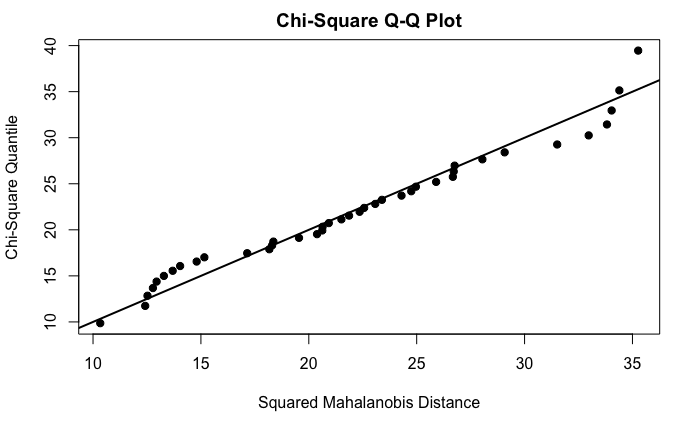

```r
mvn(select_if(recipes_small, is.double), scale = TRUE, multivariatePlot = "qq")
```

| Test | Statistic | p value | Result |
| --- | --- | --- | --- |
| Mardia Skewness | 1988.97393846384 | 0.706514894545773 | YES |
| Mardia Kurtosis | -2.01908375954359 | 0.0434785145399792 | NO |
| MVN | NA | NA | NO |

|  | Test | Variable | Statistic | p value | Normality |
| --- | --- | --- | --- | --- | --- |
| 1 | Shapiro-Wilk | baking powder | 0.8697 | 3e-04 | NO |
| 2 | Shapiro-Wilk | baking soda | 0.8132 | <0.001 | NO |
| 3 | Shapiro-Wilk | butter | 0.8348 | <0.001 | NO |
| 4 | Shapiro-Wilk | buttermilk | 0.2925 | <0.001 | NO |
| 5 | Shapiro-Wilk | chocolate | 0.6125 | <0.001 | NO |
| 6 | Shapiro-Wilk | cornmeal | 0.2965 | <0.001 | NO |
| 7 | Shapiro-Wilk | cream cheese | 0.5305 | <0.001 | NO |
| 8 | Shapiro-Wilk | eggs | 0.8933 | 0.0012 | NO |
| 9 | Shapiro-Wilk | flour | 0.9530 | 0.0965 | YES |
| 10 | Shapiro-Wilk | fruit | 0.7461 | <0.001 | NO |

[output cut: 12 more lines]

|  | n | Mean | Std.Dev | Median | Min | Max | 25th | 75th | Skew | Kurtosis |
| --- | --- | --- | --- | --- | --- | --- | --- | --- | --- | --- |
| baking powder | 40 | 0.03097813 | 0.02510343 | 0.02946276 | 0.000000 | 0.07216878 | 0.00000000 | 0.05665762 | -0.0208383073 | -1.4734040 |
| baking soda | 40 | 0.02016169 | 0.01973721 | 0.02551550 | 0.000000 | 0.05892552 | 0.00000000 | 0.04166663 | 0.1687270881 | -1.5915191 |
| butter | 40 | 0.09596949 | 0.09143286 | 0.09522521 | 0.000000 | 0.25000000 | 0.00000000 | 0.20412415 | 0.2118061363 | -1.6018520 |
| buttermilk | 40 | 0.01530931 | 0.05444946 | 0.00000000 | 0.000000 | 0.20412415 | 0.00000000 | 0.00000000 | 3.1068790828 | 7.8508277 |
| chocolate | 40 | 0.05592116 | 0.10142763 | 0.00000000 | 0.000000 | 0.35355339 | 0.00000000 | 0.09196278 | 1.5829995421 | 1.3973511 |
| cornmeal | 40 | 0.02068376 | 0.07373792 | 0.00000000 | 0.000000 | 0.28867513 | 0.00000000 | 0.00000000 | 3.1317733633 | 8.0675897 |
| cream cheese | 40 | 0.03837069 | 0.08124465 | 0.00000000 | 0.000000 | 0.28867513 | 0.00000000 | 0.00000000 | 1.7467145546 | 1.5423483 |
| eggs | 40 | 0.36161893 | 0.16232314 | 0.35355339 | 0.000000 | 0.79056942 | 0.28867513 | 0.40824829 | 0.1703981233 | 1.4355493 |
| flour | 40 | 0.32434909 | 0.07277941 | 0.32274861 | 0.102062 | 0.45643546 | 0.28867513 | 0.38188131 | -0.5981441132 | 0.6056500 |
| fruit | 40 | 0.10961834 | 0.14175418 | 0.00000000 | 0.000000 | 0.40824829 | 0.00000000 | 0.21559311 | 0.7145055368 | -1.1550476 |

[output cut: 12 more lines]

```
NA
```

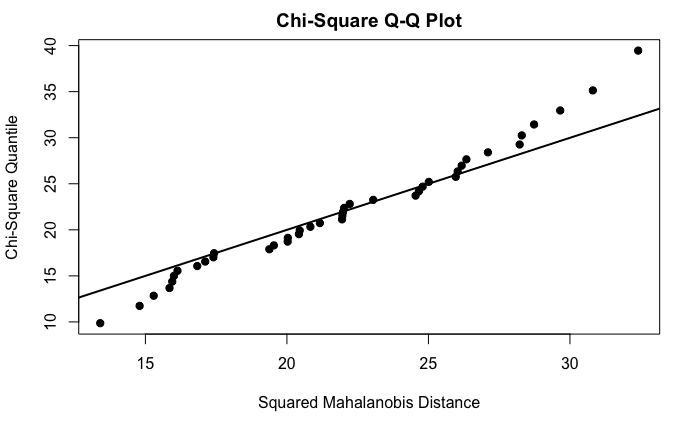

```r
mvn(select_if(recipes_small, is.double), scale = TRUE, transform = "sqrt", multivariatePlot = "qq")
```

```r
pca_small <- opls(select_if(recipes_small, is.double))
```

```
PCA
40 samples x 22 variables
standard scaling of predictors
```

|  | R2X(cum) | pre | ort |
| --- | --- | --- | --- |
| Total | 0.542 | 5 | 0 |

```
OPLS-DA
40 samples x 22 variables and 1 response
standard scaling of predictors and response(s)
```

|  | R2X(cum) | R2Y(cum) | Q2(cum) | RMSEE | pre | ort | pR2Y | pQ2 |
| --- | --- | --- | --- | --- | --- | --- | --- | --- |
| Total | 0.185 | 0.751 | 0.488 | 0.259 | 1 | 1 | 0.005 | 0.005 |

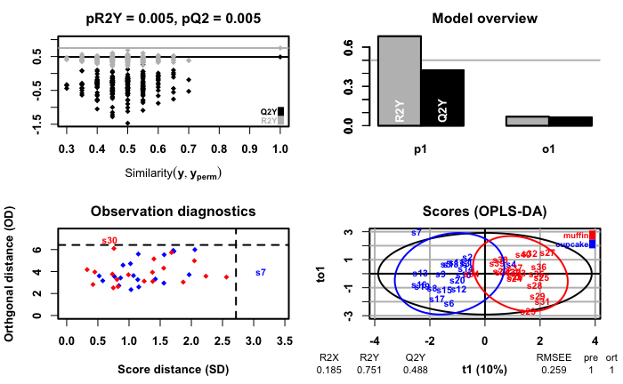

```r
#pls-da gives a single component model, so do opls-da for the sake of getting a plot.
oplsda_small <- opls(select_if(recipes_small, is.double), recipes_small$Type,
                     permI = 200,
                     predI = 1,
                     orthoI = NA)
```

```r
pca_plotdata <- get_plotdata(pca_small)
oplsda_plotdata <- get_plotdata(oplsda_small)
```

[output not shown]

```r
pca.plot <- ggplot(pca_plotdata$plot_data, aes(x = p1, y = p2 * -1, color = recipes_small$Type)) +
  geom_point() +
  stat_ellipse() +
  labs(x = paste0("PC1 (", pca_plotdata$var_explained$R2X[1] * 100,"%)"),
       y = paste0("PC2 (", pca_plotdata$var_explained$R2X[2] * 100, "%)")) +
  scale_color_discrete("Recipe Type", labels = c("Cupcake", "Muffin")) +
  theme_bw()
```

```r
opls.plot <- ggplot(oplsda_plotdata$plot_data, aes(x = p1, y = o1, color = y1)) +
  geom_point() +
  stat_ellipse() +
  labs(x = paste0("Predictive Axis (", oplsda_plotdata$axis_stats$R2X[1] * 100,"%)"),
       y = paste0("Orthogonal Axis (", oplsda_plotdata$axis_stats$R2X[2] * 100, "%)")) +
  scale_color_discrete("Recipe Type", labels = c("Cupcake", "Muffin")) +
  theme_bw() +
  ggtitle(label = NULL,
          subtitle = TeX(paste0(
            "$R^{2}_Y = ", oplsda_plotdata$model_stats$`R2Y(cum)`, "$; ",
            "$Q^2 = ", oplsda_plotdata$model_stats$`Q2(cum)`, "$; ",
            "$p_{Q^2} = ", oplsda_plotdata$model_stats$pQ2, "$")))
```

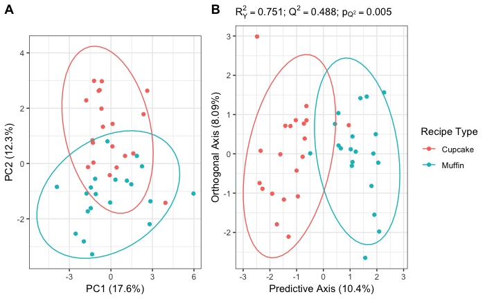

```r
cupcake_plot <- plot_grid(pca.plot + theme(legend.position = "none") + ggtitle("", ""),
          opls.plot + theme(legend.position = "none"),
          get_legend(opls.plot),
          ncol = 3,
          rel_widths = c(1, 1, 0.35),
          labels = c("A", "B", ""))
cupcake_plot
save_plot(here("figs", "cupcakeplot.png"), cupcake_plot, ncol = 2, base_height = 3)
```

```r
VIPs <- get_VIP(oplsda_small) %>%
  arrange(desc(VIP))
opls_loadings <- getLoadingMN(oplsda_small) %>%
  as.data.frame() %>%
  rownames_to_column(var = "Variable") %>%
  arrange(desc(p1))
pca_loadings <- getLoadingMN(pca_small) %>%
  as.data.frame() %>%
  rownames_to_column(var = "Variable") %>%
  arrange(desc(p2))
variation <- recipes_small %>%
  select_if(is.double) %>%
  summarise_all(sd) %>%
  gather(key = "Variable", value = "Standard Deviation")
table2 <- left_join(VIPs, opls_loadings) %>%
  rename("OPLS-DA Predictive Axis Loading" = p1) %>%
  left_join(pca_loadings %>%
              dplyr::select(Variable, p1, p2)) %>%
  rename("PC1 Loading" = p1, "PC2 Loading" = p2) %>%
  left_join(variation)
```

Need to scale PC loadings to match axis of OPLS-DA? Is standard deviation helpful at all?

```r
table2 %>%
  select(-`Standard Deviation`) %>%
  select_if(is.double) %>%
  map2_df(.y = c(2,3,3,3), .f = ~round(.x, .y)) %>%
  add_column(Variable = table2$Variable) %>%
  select(Variable, everything()) %>%
  write_csv(here("figs", "table2.csv"))
```

# Results

PCA and OPLS-DA both show some separation between cupcakes and muffins, but there are substantial differences in the two methods. First, although PC1 explains the greatest amount of covariation in the ingredients, it does not show any separation between cupcakes and muffins. PC2 shows some weak separation between cupcakes and muffins. This indicates that the variables with the greatest (co)variation in the dataset are not good predictors of the type of baked good. Even when comparing PC2, which separates cupcakes and muffins, with the OPLS-DA predictive axis, there are substantial differences. For example, “unitless” ingredients (e.g. “one sweet potato”, “25 blueberries”) are strongly negatively correlated with PC2 (toward muffins), however, it is not a good predictor of muffins vs. cupcakes as evidenced by its low VIP score and its weak correlation with the OPLS-DA predictive axis. Conversely, “spice” is a good predictor of muffins vs. cupcakes (muffins have more spices than cupcakes) as evidenced by a VIP greater than 1 and a stronger correlation with the OPLS-DA predictive axis, but have a weak correlation with PC2.